# Praca domowa 2

## Zadanie 5

Rozważmy tylko nieruchomości, które miały remont. W której dekadzie było najwięcej przeprowadzonych remontów? Czy w poszczególnych dekadach jest porównywalny procent nieruchmości dla każdej wartości miary jakości i wykończenia nieruchomości?

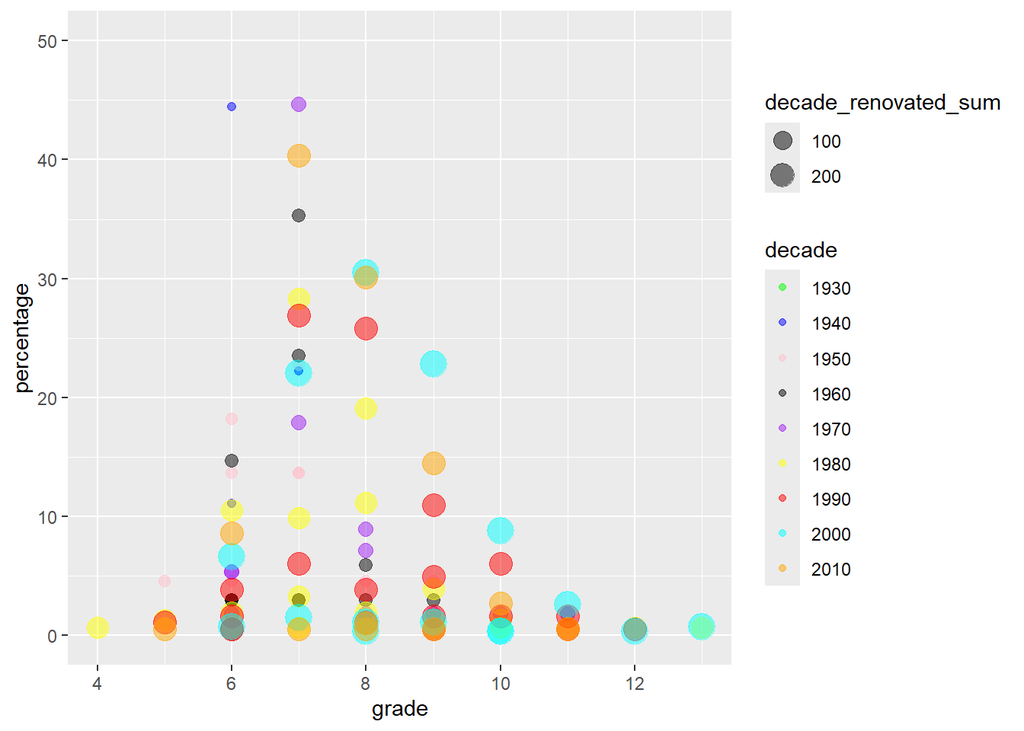

```r
tmp <- renovated <- df %>%
  filter(yr_renovated != 0) %>%
  mutate(decade = yr_renovated %/% 10 * 10) %>%
  select(decade, grade, condition)

renovated <- df %>%
  filter(yr_renovated != 0) %>%
  mutate(decade = yr_renovated %/% 10 * 10) %>%
  group_by(decade) %>%
  summarise(decade_renovated_sum = n()) %>%
  left_join(tmp, by = 'decade') %>%
  group_by(decade, decade_renovated_sum, grade, condition) %>%
  summarise(count = n(),  .groups = 'drop') %>%
  mutate(percentage = count/decade_renovated_sum * 100) %>%
  mutate(decade = as.factor(decade))

#skoro nasze wartsci sa pogrupowane tak ze grade oraz condition byly razem, to do oszacowania czy taki sam procent w danej dekadzie wystarczy nam jedna wartosc
ggplot(renovated, aes(x = grade, y = percentage, color = decade, size = decade_renovated_sum)) +
  scale_color_manual(values = c("1930" = "green", "1940" = "blue","1950" = "pink", "1960" = "black", "1970" = "purple", "1980" = "yellow", "1990" = "red", "2000" = "cyan", "2010" = "orange")) +
  scale_y_continuous(labels = scales::comma, limits = c(0, 50)) +
  geom_point(alpha = 0.5)
```

**Komentarz:** Widzimy, że największe kropki ma kolor cyanowy, czyli najwięcej remontów było w dekadzie 2000. W ramce danych na ktorej operujemy, grade oraz condition bylo pogrupowae razem, dlatego wystarczy nam tylko jedna z tych danych aby sprawdzic wynik naszego badania. Widzimy, ze dla roznych dekad mamy inne procenty (w ktorych uwzgledniane bylo grade oraz condition). Wartosci nakładają się tylko na percentage = 0, na innych wartosiach się nie pokrywają, są mocno zróćnicowane -> zatem odpowiedź na pytanie z treści zadania jest negująca.

## Zadanie 6

Jak prezentuje się wartość minimalna, średnia i maksymalna ceny nieruchmości w podziele na rok budowy nieruchomości.

[figure not shown]

```r
df_6 <- df %>%
  mutate(year = substr(date, 1, 4)) %>%
  group_by(year) %>%
  summarise(min_price = min(price), max_price = max(price), avg_price = mean(price))

plot_6 <- ggplot(df_6, aes(x = year)) +
  geom_point(aes(y = min_price, color = "Minimalna Cena")) +
  geom_point(aes(y = max_price, color = "Maksymalna Cena")) +
  geom_point(aes(y = avg_price, color = "Średnia Cena")) +
  labs(title = "Minimalna, Maksymalna i Średnia Cena Nieruchomości w Podziale na Rok",
       x = "Rok Budowy",
       y = "Cena",
       color = "Typ Ceny") +
  scale_y_continuous(labels = scales::comma, limits = c(0, 8000000))
plot_6
```

**Komentarz:** Widzimy, ze w obu latach srednia oraz minimalna cena byly praktycznie porownywalne, nie widac znaczącej różnicy. Różni się za to cena maksymalna, rok 2014 zdecydowanie przewyższa rok 2015